# Epistemología de la investigación

Una introducción a la epistemología de la interdisciplinariedad

## Descripción del seminario

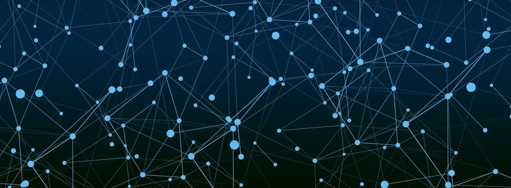

El objetivo general de este seminario es examinar los métodos, metodologías y competencias para investigar en el campo que comprende la unión de las ciencias experimentales, sociales y humanas usualmente conocido como *interdisciplinariedad* con miras a la integración de consideraciones sobre cultura, fe y ciencia. Estudiaremos la idea de una disciplina, su forma de investigar y cómo se puede caracterizar la investigación que no se ajusta a tales maneras. En el contexto de la [Maestría en Teología](https://www.unisabana.edu.co/index.php?id=12310), la idea es ofrecer al estudiante las bases para una investigación que no solo abarque las diversas áreas de la Teología, sino también de las ciencias sociales, humanas o experimentales.

Discutiremos los valores de una disciplina, la forma en que las metodologías propias de una disciplina deben relacionarse con otras, la noción de evidencia, la relación entre la investigación, el sujeto y el objeto de estudio, la necesidad de la neutralidad en la investigación y la relación de la investigación académica con los llamados “problemas reales”.

Para ello, primero examinaremos el rol general de la discusión epistemológica en la maestría y hablaremos sobre las disciplinas base de quienes compongan el seminario, estas son aquellas que estudiaron durante su pregrado o la mayor parte de sus estudios, en la que se han desempeñado principalmente o con la que mejor se identifican. Después utilizaremos un cuestionario para guiar la discusión sobre la forma en que se investiga en cada una de sus disciplinas (basado en Hubbs, G., O’Rourke, M., & Orzack, S. H. (2020)) y la manera en que creen que esto enmarca también su futura investigación a lo largo de la Maestría en Teología. Posteriormente, discutiremos la tensión en la investigación disciplinar y su aplicabilidad a los “problemas reales” (con un espacio en donde discutiremos también la idoneidad de la noción de “problemas reales”). Para finalizar hablaremos sobre la idea misma de la disciplinariedad y las formas en que podemos caracterizar la diferencias con la interdisciplinariedad, transdisciplinariedad y multidisciplinariedad y otras formas de investigación por fuera de los esquemas presentados por una disciplina. Terminaremos con un retorno al cuestionario inicial con miras a determinar la forma en que su aproximación a la investigación ha cambiado a luz del seminario y la forma en que formularía una investigación sobre fe, ciencia y cultura dentro del marco epistemológico presentado.

**Profesor**: Juan Camilo Espejo-Serna

**Página web**: http://jcunisabana.github.io/epistemologia

**Horario**: Lunes 18 - Sábado 23, Enero 2021, 4:00 - 6:00 pm

**Grupo de MS Teams**: https://tinyurl.com/yyf7mjr9

## Objetivos

- Leer críticamente textos académicos que permitan desarrollar hábitos intelectuales.
- Discernir el ámbito general del tipo de investigación que realizará a lo largo del programa académico.
- Producir un ensayo corto (máximo 2000 palabras) en donde formule una pregunta bien definida y determine la metodología que va a seguir para responderla.

## Sesiones

### Sesión 1

| Tema | Pregunta central |
| --- | --- |
| Presentación general del curso y del cuestionario sobre su disciplina | ¿Qué buscan con sus estudios de maestría? |

[interactive chart not shown]

Presentación en pantalla completa

### Sesión 2

| Tema | Pregunta central |
| --- | --- |
| Discusión en clase con base Michael O’Rourke & Stephen Crowley (2020) y Marisa Rinkus & Stephanie Vasko (2020) | ¿Cómo es su disciplina base? |

[interactive chart not shown]

Presentación en pantalla completa

### Sesión 3

| Tema | Pregunta central |
| --- | --- |
| Presentación y discusión con base en Wolfagan Krohn (2017) | ¿Qué retos enfrenta la investigación interdisciplinar? |

[interactive chart not shown]

Presentación en pantalla completa

### Sesión 4

[output not shown]

[interactive chart not shown]

Presentación en pantalla completa

### Sesión 5

[output not shown]

[interactive chart not shown]

Presentación en pantalla completa

### Sesión 6

| Tema | Pregunta central |
| --- | --- |
| Revisión de la discusión con base Michael O’Rourke & Stephen Crowley (2020) y Marisa Rinkus & Stephanie Vasko (2020) | ¿Cómo formular una pregunta de investigación? |

[interactive chart not shown]

Presentación en pantalla completa

## Evaluación

#### **Reseña crítica**

El **2 de Marzo** deberán entregar un escrito en donde tomen uno de los textos de la bibliografía sobre interdisciplinariedad y relacionen ese tipo de consideraciones con el estudio de una cuestión de fe, ciencia y cultura.

Se evaluarán dos aspectos: la presentación apropiada de la pregunta general por la relación entre disciplinas y la forma en que se establece la relación con alguna cuestión Teológica.

#### **Participación activa**

El diálogo es esencial para el desarrollo de la materia pues será gracias a éste que podremos ver en acción los retos que presenta la integración de diferentes perspectivas.

Habrá tres actividades en las que tendrán que participar, ofreciendo su punto de vista de manera argumentada y dialogando con las opiniones de sus compañeros. Si se participa en todas, la nota será 5. Si se participa en dos, la nota será de 3.5, si se participa en 1, la nota será de 2.0.

#### **Ensayo**

Extensión: entre 1000 y 2000 palabras.

El **2 de Mayo** deberán entregar un ensayo corto en el que tomen los temas de disciplinariedad e interdisciplininariedad y presenten una pregunta teológica bien definida y una sólida y precisa caracterización de la metodología que emplearían para responderla. (Es una nueva versión de la reseña crítica en donde ahora incorporan todo lo visto en el curso y una investigación propia.)

Se evaluarán dos aspectos: la presentación apropiada de la pregunta general por la relación entre disciplinas y la forma en que se establece la relación con alguna cuestión Teológica.

#### **Incumplimiento**

*La vida nos da sorpresas; sorpresas nos da la vida.* Por eso, si por alguna razón no pueden cumplir con las fechas exigidas para los trabajos, es importante avisar al profesor con tiempo. Hablemos. No me tienen que contar todos los detalles de sus problemas pero es importante que si se encuentran en una situación en la que ven que no pueden cumplir con los requerimientos del seminario me avisen con la mayor anticipación posible y encontremos un plan para solventar el problema en lo que respecta a la clase. Insisto: hablemos, no se pierdan **:)** .

#### **Calificación**

| Reseña crítica | Participación activa | Ensayo |
| --- | --- | --- |
| 15% | 15% | 70% |

## Bibliografía

- O’Rourke, Michael, Troy E. Hall, and Bethany K. Laursen. 2020. “The Power of Dialogue.” In The Toolbox Dialogue Initiative. https://doi.org/10.4324/9780429440014-7.
- Frodeman, Robert. 2013. Sustainable Knowledge: A Theory of Interdisciplinarity. Sustainable Knowledge: A Theory of Interdisciplinarity. https://doi.org/10.1057/9781137303028.
- O’Rourke, Michael, and Stephen Crowley. 2020. “How It Works: The Toolbox Dialogue Method in Practice.” In The Toolbox Dialogue Initiative, 17–36.
- Gonnerman, Chad, Graham Hubbs, Bethany K. Laursen, and Anna Malavisi. 2020. “The Power of Philosophy.” In The Toolbox Dialogue Initiative. https://doi.org/10.4324/9780429440014-6.
- Hubbs, Graham, Michael O’Rourke, and Steven Heck Orzack, eds. 2020. The Toolbox Dialogue Initiative. The Toolbox Dialogue Initiative. https://doi.org/10.1201/9780429440014.
- Rinkus, Marisa A., and Stephanie E. Vasko. 2020. “Best Practices for Planning and Running a Toolbox Workshop.” In The Toolbox Dialogue Initiative. https://doi.org/10.4324/9780429440014-8.
- Brazal, Agnes M, and Daniel Franklin Pilario. 2008. “Disciplines, Interdisciplinarity and Theology.” Hapág: A Journal of Interdisciplinary Theological Research. https://doi.org/10.3860/hapag.v4i1.657.
- Krohn, Wolfgang. 2010. “Interdisciplinary Cases and Disciplinary Knowledge.” In The Oxford Handbook of Interdisciplinarity. Oxford.
- Frodeman, Robert. 2017. The Oxford Handbook of Interdisciplinarity 2nd Ed. Oxford Handbook.
- Stone, Howard W., and James O. Duke. 2018. How to Think Theologically. https://doi.org/10.2307/j.ctt22nmb9s.